# 永和區PM2.5和氣象資料比較關係

陳哲偉

2019年7月11日

#### 研究目的:因為這幾年空氣品質很差，網路上就有人說是因為大陸的髒空氣吹過來的，於是我就蒐集的各縣市的[PM2.5]和[風向]來做比較，看看會不會在吹某個風向的時候空氣品質最差!

###### 資料來源 [空氣品質監測網](https://taqm.epa.gov.tw/taqm/tw/YearlyDataDownload.aspx),[觀測資料查詢](https://e-service.cwb.gov.tw/HistoryDataQuery/index.jsp)

# 設定檔案位置和載入套件

```r
library(dplyr)
```

```r
library(ggplot2)
setwd("C:/Users/jeff6/Desktop/Github/alan/Week2-1")
```

# 各縣市的[PM2.5]和[風向]畫成的散佈圖

#### (滿多的~可以滑到最下面看結論)

#————————————————————————————–台北

```r
a <- read.csv("空氣品質監測小時值台北.csv")
```

#刪除多的一行(台北的數據)

```r
a = a[-51, ]
```

#選出需要的測項

```r
TEMP = filter(a, 測項.單位. %in% "溫度 AMB_TEMP (℃)")
WD = filter(a, 測項.單位. %in% "風向 WIND_DIREC (degrees)")
PM = filter(a, 測項.單位. %in% "細懸浮微粒 PM 2.5  (μg/m 3 )")
RH = filter(a, 測項.單位. %in% "相對濕度 RH (percent)")
```

#刪除1~6不要的數據

```r
for (x in (1:6))
{
  TEMP <- TEMP[ ,-1]
  WD <- WD[ ,-1]
  PM <- PM[ ,-1]
  RH <- RH[ ,-1]
}
```

#取數值

```r
TPTEMP <- filter(TEMP[1, ])
TPWD <- filter(WD[1, ])
TPPM <- filter(PM[1, ])
TPRH <- filter(RH[1, ])
```

#再和其他的合成一行

```r
for (i in 2:6)
{
  TPTEMP <- cbind(TPTEMP,filter(TEMP[i, ]))
  TPWD <- cbind(TPWD,filter(WD[i, ]))
  TPPM <- cbind(TPPM,filter(PM[i, ]))
  TPRH <- cbind(TPRH,filter(RH[i, ]))
}


TPTEMP <- t(TPTEMP)
TPTEMP <- data.frame(TPTEMP)
TPWD <- t(TPWD)
TPWD <- data.frame(TPWD)
TPPM <- t(TPPM)
TPPM <- data.frame(TPPM)
TPRH <- t(TPRH)
TPRH <- data.frame(TPRH)
```

#合併total

```r
TPtotal <- bind_cols(TPTEMP,TPWD,TPPM,TPRH)
```

#照數字大小排列!!沒做的話,排序會怪怪的

```r
TPtotal$TPPM <- factor(TPtotal$TPPM, levels = c(1:50 ), ordered = TRUE )
TPtotal$TPWD <- factor(TPtotal$TPWD, levels = c(1:360 ), ordered = TRUE )
```

#散佈圖

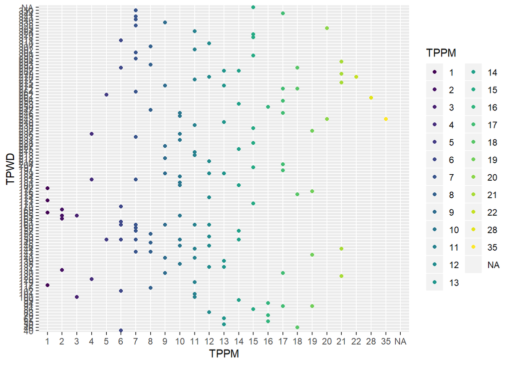

```r
ggplot(data = TPtotal)+
  geom_point(aes(x=TPPM,y=TPWD,color=TPPM))
```

# ——————————————————————————-台北ggplot

#——————————————————————————————新北

```r
a <- read.csv("空氣品質監測小時值新北.csv")
```

#選出需要的測項

```r
TEMP = filter(a, 測項.單位. %in% "溫度 AMB_TEMP (℃)")
WD = filter(a, 測項.單位. %in% "風向 WIND_DIREC (degrees)")
PM = filter(a, 測項.單位. %in% "細懸浮微粒 PM 2.5  (μg/m 3 )")
RH = filter(a, 測項.單位. %in% "相對濕度 RH (percent)")
```

#刪除1~6不要的數據

```r
for (x in (1:6))
{
  TEMP <- TEMP[ ,-1]
  WD <- WD[ ,-1]
  PM <- PM[ ,-1]
  RH <- RH[ ,-1]
}
```

#刪除多的一行(新北的數據)

```r
PM = PM[-1, ]
RH = RH[-1, ]
TEMP = TEMP[-1, ]
```

#取數值

```r
NTTEMP <- filter(TEMP[1, ])
NTWD <- filter(WD[1, ])
NTPM <- filter(PM[1, ])
NTRH <- filter(RH[1, ])
```

#再和其他的合成一行

```r
for (i in 2:11)
{
  NTTEMP <- cbind(NTTEMP,filter(TEMP[i, ]))
  NTWD <- cbind(NTWD,filter(WD[i, ]))
  NTPM <- cbind(NTPM,filter(PM[i, ]))
  NTRH <- cbind(NTRH,filter(RH[i, ]))
}

NTTEMP <- t(NTTEMP)
NTTEMP <- data.frame(NTTEMP)
NTWD <- t(NTWD)
NTWD <- data.frame(NTWD)
NTPM <- t(NTPM)
NTPM <- data.frame(NTPM)
NTRH <- t(NTRH)
NTRH <- data.frame(NTRH)
```

#合併total

```r
NTtotal <- bind_cols(NTTEMP,NTWD,NTPM,NTRH)
```

#照數字大小排列!!沒做的話,排序會怪怪的

```r
NTtotal$NTPM <- factor(NTtotal$NTPM, levels = c(1:50 ), ordered = TRUE )
NTtotal$NTWD <- factor(NTtotal$NTWD, levels = c(1:360 ), ordered = TRUE )
```

#散佈圖

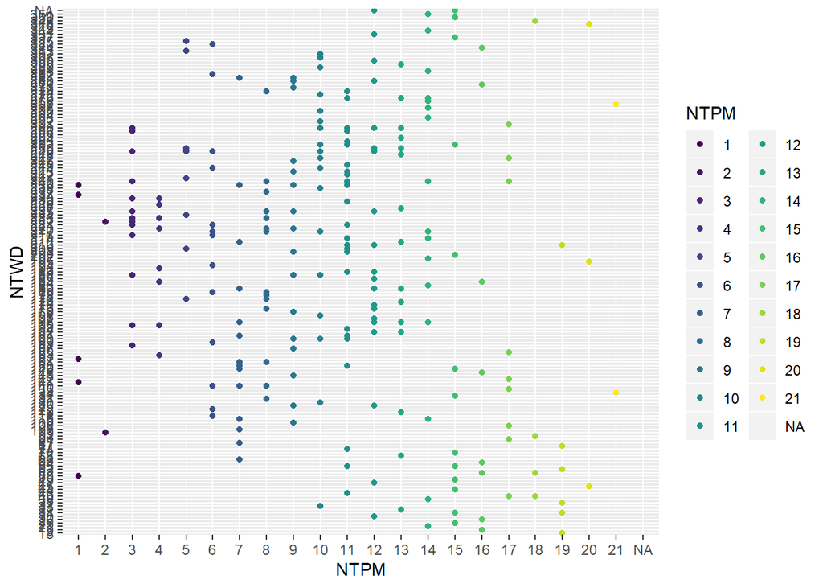

```r
ggplot(data = NTtotal)+
  geom_point(aes(x=NTPM,y=NTWD,color=NTPM))
```

# ——————————————————————————-新北ggplot

#——————————————————————————————台中

```r
a <- read.csv("空氣品質監測小時值台中.csv")
```

#選出需要的測項

```r
TEMP = filter(a, 測項.單位. %in% "溫度 AMB_TEMP (℃)")
WD = filter(a, 測項.單位. %in% "風向 WIND_DIREC (degrees)")
PM = filter(a, 測項.單位. %in% "細懸浮微粒 PM 2.5  (μg/m 3 )")
RH = filter(a, 測項.單位. %in% "相對濕度 RH (percent)")
```

#刪除1~6不要的數據

```r
for (x in (1:6))
{
  TEMP <- TEMP[ ,-1]
  WD <- WD[ ,-1]
  PM <- PM[ ,-1]
  RH <- RH[ ,-1]
}
```

#取數值

```r
TCTEMP <- filter(TEMP[1, ])
TCWD <- filter(WD[1, ])
TCPM <- filter(PM[1, ])
TCRH <- filter(RH[1, ])
```

#再和其他的合成一行

```r
for (i in 2:5)
{
  TCTEMP <- cbind(TCTEMP,filter(TEMP[i, ]))
  TCWD <- cbind(TCWD,filter(WD[i, ]))
  TCPM <- cbind(TCPM,filter(PM[i, ]))
  TCRH <- cbind(TCRH,filter(RH[i, ]))
}

TCTEMP <- t(TCTEMP)
TCTEMP <- data.frame(TCTEMP)
TCWD <- t(TCWD)
TCWD <- data.frame(TCWD)
TCPM <- t(TCPM)
TCPM <- data.frame(TCPM)
TCRH <- t(TCRH)
TCRH <- data.frame(TCRH)
```

#合併total

```r
TCtotal <- bind_cols(TCTEMP,TCWD,TCPM,TCRH)
```

#照數字大小排列!!沒做的話,排序會怪怪的

```r
TCtotal$TCPM <- factor(TCtotal$TCPM, levels = c(1:50 ), ordered = TRUE )
TCtotal$TCWD <- factor(TCtotal$TCWD, levels = c(1:360 ), ordered = TRUE )
```

#散佈圖

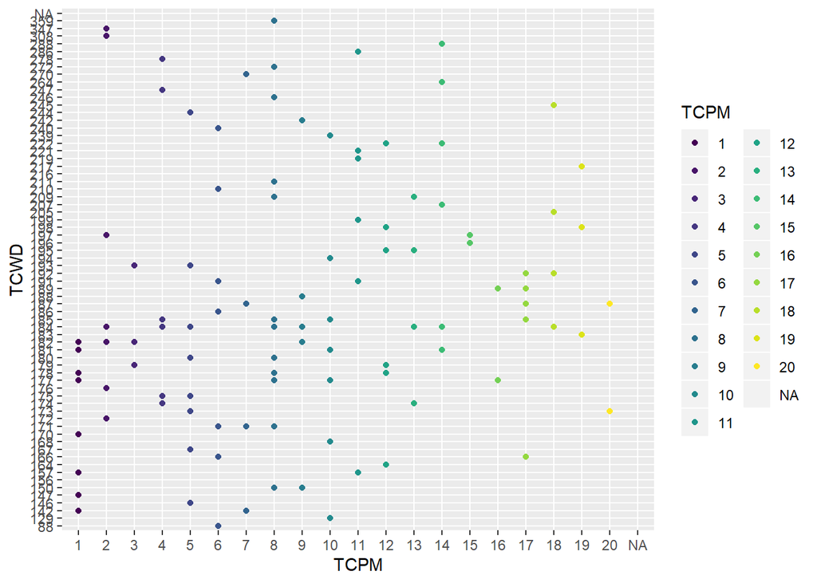

```r
ggplot(data = TCtotal)+
  geom_point(aes(x=TCPM,y=TCWD,color=TCPM))
```

# ——————————————————————————-台中ggplot

#——————————————————————————————台東

```r
a <- read.csv("空氣品質監測小時值台東.csv")
```

#選出需要的測項

```r
TEMP = filter(a, 測項.單位. %in% "溫度 AMB_TEMP (℃)")
WD = filter(a, 測項.單位. %in% "風向 WIND_DIREC (degrees)")
PM = filter(a, 測項.單位. %in% "細懸浮微粒 PM 2.5  (μg/m 3 )")
RH = filter(a, 測項.單位. %in% "相對濕度 RH (percent)")
```

#刪除1~6不要的數據

```r
for (x in (1:6))
{
  TEMP <- TEMP[ ,-1]
  WD <- WD[ ,-1]
  PM <- PM[ ,-1]
  RH <- RH[ ,-1]
}
```

#取數值

```r
TTTEMP <- filter(TEMP[1, ])
TTWD <- filter(WD[1, ])
TTPM <- filter(PM[1, ])
TTRH <- filter(RH[1, ])
```

#再和其他的合成一行

```r
for (i in 2)
{
  TTTEMP <- cbind(TTTEMP,filter(TEMP[i, ]))
  TTWD <- cbind(TTWD,filter(WD[i, ]))
  TTPM <- cbind(TTPM,filter(PM[i, ]))
  TTRH <- cbind(TTRH,filter(RH[i, ]))
}

TTTEMP <- t(TTTEMP)
TTTEMP <- data.frame(TTTEMP)
TTWD <- t(TTWD)
TTWD <- data.frame(TTWD)
TTPM <- t(TTPM)
TTPM <- data.frame(TTPM)
TTRH <- t(TTRH)
TTRH <- data.frame(TTRH)
```

#合併total

```r
TTtotal <- bind_cols(TTTEMP,TTWD,TTPM,TTRH)
```

#照數字大小排列!!沒做的話,排序會怪怪的

```r
TTtotal$TTPM <- factor(TTtotal$TTPM, levels = c(1:50 ), ordered = TRUE )
TTtotal$TTWD <- factor(TTtotal$TTWD, levels = c(1:360 ), ordered = TRUE )
```

#散佈圖

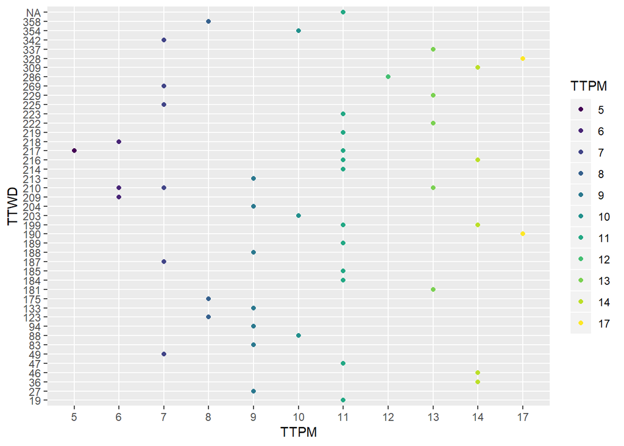

```r
ggplot(data = TTtotal)+
  geom_point(aes(x=TTPM,y=TTWD,color=TTPM))
```

# ——————————————————————————-台東ggplot

#——————————————————————————————台南

```r
a <- read.csv("空氣品質監測小時值台南.csv")
```

#選出需要的測項

```r
TEMP = filter(a, 測項.單位. %in% "溫度 AMB_TEMP (℃)")
WD = filter(a, 測項.單位. %in% "風向 WIND_DIREC (degrees)")
PM = filter(a, 測項.單位. %in% "細懸浮微粒 PM 2.5  (μg/m 3 )")
RH = filter(a, 測項.單位. %in% "相對濕度 RH (percent)")
```

#刪除1~6不要的數據

```r
for (x in (1:6))
{
  TEMP <- TEMP[ ,-1]
  WD <- WD[ ,-1]
  PM <- PM[ ,-1]
  RH <- RH[ ,-1]
}
```

#取數值

```r
TNTEMP <- filter(TEMP[1, ])
TNWD <- filter(WD[1, ])
TNPM <- filter(PM[1, ])
TNRH <- filter(RH[1, ])
```

#再和其他的合成一行

```r
for (i in 2:4)
{
  TNTEMP <- cbind(TNTEMP,filter(TEMP[i, ]))
  TNWD <- cbind(TNWD,filter(WD[i, ]))
  TNPM <- cbind(TNPM,filter(PM[i, ]))
  TNRH <- cbind(TNRH,filter(RH[i, ]))
}

TNTEMP <- t(TNTEMP)
TNTEMP <- data.frame(TNTEMP)
TNWD <- t(TNWD)
TNWD <- data.frame(TNWD)
TNPM <- t(TNPM)
TNPM <- data.frame(TNPM)
TNRH <- t(TNRH)
TNRH <- data.frame(TNRH)
```

#合併total

```r
TNtotal <- bind_cols(TNTEMP,TNWD,TNPM,TNRH)
```

#照數字大小排列!!沒做的話,排序會怪怪的

```r
TNtotal$TNPM <- factor(TNtotal$TNPM, levels = c(1:50 ), ordered = TRUE )
TNtotal$TNWD <- factor(TNtotal$TNWD, levels = c(1:360 ), ordered = TRUE )
```

#散佈圖

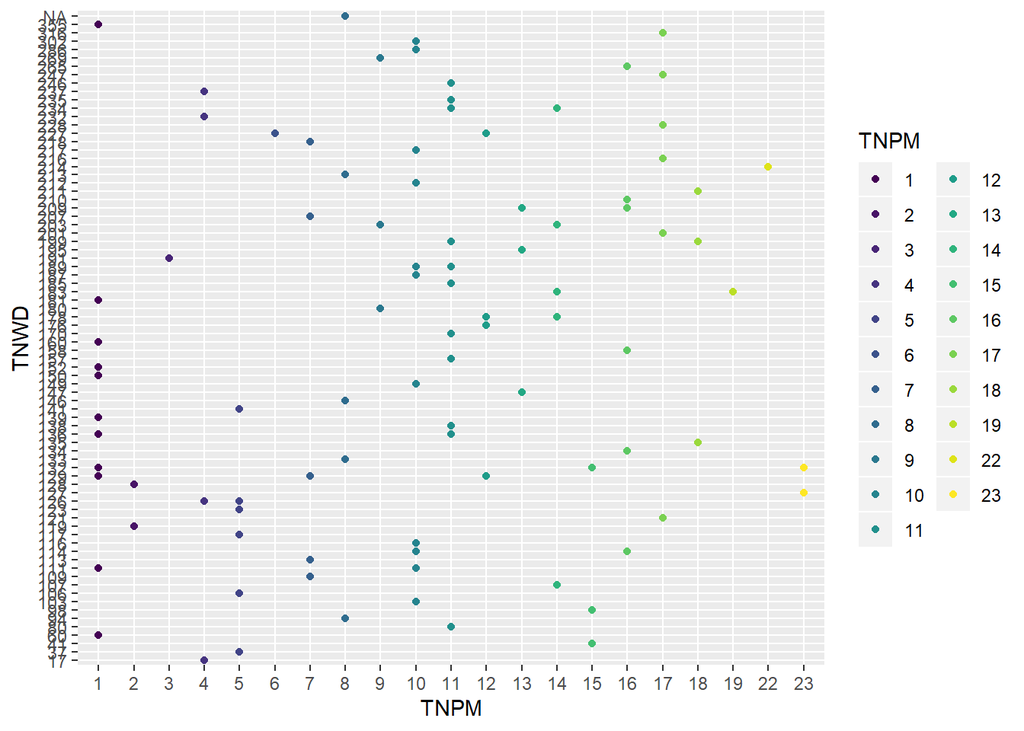

```r
ggplot(data = TNtotal)+
  geom_point(aes(x=TNPM,y=TNWD,color=TNPM))
```

# ——————————————————————————-台南ggplot

#——————————————————————————————宜蘭

```r
a <- read.csv("空氣品質監測小時值宜蘭.csv")
```

#選出需要的測項

```r
TEMP = filter(a, 測項.單位. %in% "溫度 AMB_TEMP (℃)")
WD = filter(a, 測項.單位. %in% "風向 WIND_DIREC (degrees)")
PM = filter(a, 測項.單位. %in% "細懸浮微粒 PM 2.5  (μg/m 3 )")
RH = filter(a, 測項.單位. %in% "相對濕度 RH (percent)")
```

#刪除1~6不要的數據

```r
for (x in (1:6))
{
  TEMP <- TEMP[ ,-1]
  WD <- WD[ ,-1]
  PM <- PM[ ,-1]
  RH <- RH[ ,-1]
}
```

#取數值

```r
ILTEMP <- filter(TEMP[1, ])
ILWD <- filter(WD[1, ])
ILPM <- filter(PM[1, ])
ILRH <- filter(RH[1, ])
```

#再和其他的合成一行

```r
for (i in 2)
{
  ILTEMP <- cbind(ILTEMP,filter(TEMP[i, ]))
  ILWD <- cbind(ILWD,filter(WD[i, ]))
  ILPM <- cbind(ILPM,filter(PM[i, ]))
  ILRH <- cbind(ILRH,filter(RH[i, ]))
}

ILTEMP <- t(ILTEMP)
ILTEMP <- data.frame(ILTEMP)
ILWD <- t(ILWD)
ILWD <- data.frame(ILWD)
ILPM <- t(ILPM)
ILPM <- data.frame(ILPM)
ILRH <- t(ILRH)
ILRH <- data.frame(ILRH)
```

#合併total

```r
ILtotal <- bind_cols(ILTEMP,ILWD,ILPM,ILRH)
```

#照數字大小排列!!沒做的話,排序會怪怪的

```r
ILtotal$ILPM <- factor(ILtotal$ILPM, levels = c(1:50 ), ordered = TRUE )
ILtotal$ILWD <- factor(ILtotal$ILWD, levels = c(1:360 ), ordered = TRUE )
```

#散佈圖

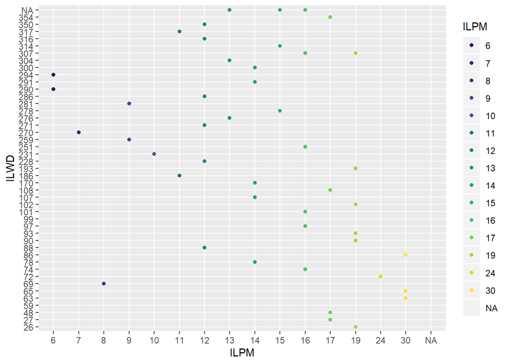

```r
ggplot(data = ILtotal)+
  geom_point(aes(x=ILPM,y=ILWD,color=ILPM))
```

# ——————————————————————————-宜蘭ggplot

#——————————————————————————————花蓮

```r
a <- read.csv("空氣品質監測小時值花蓮.csv")
```

#選出需要的測項

```r
TEMP = filter(a, 測項.單位. %in% "溫度 AMB_TEMP (℃)")
WD = filter(a, 測項.單位. %in% "風向 WIND_DIREC (degrees)")
PM = filter(a, 測項.單位. %in% "細懸浮微粒 PM 2.5  (μg/m 3 )")
RH = filter(a, 測項.單位. %in% "相對濕度 RH (percent)")
```

#刪除1~6不要的數據

```r
for (x in (1:6))
{
  TEMP <- TEMP[ ,-1]
  WD <- WD[ ,-1]
  PM <- PM[ ,-1]
  RH <- RH[ ,-1]
}
```

#取數值

```r
HLTEMP <- filter(TEMP[1, ])
HLWD <- filter(WD[1, ])
HLPM <- filter(PM[1, ])
HLRH <- filter(RH[1, ])


HLTEMP <- t(HLTEMP)
HLTEMP <- data.frame(HLTEMP)
HLWD <- t(HLWD)
HLWD <- data.frame(HLWD)
HLPM <- t(HLPM)
HLPM <- data.frame(HLPM)
HLRH <- t(HLRH)
HLRH <- data.frame(HLRH)
```

#合併total

```r
HLtotal <- bind_cols(HLTEMP,HLWD,HLPM,HLRH)
```

#照數字大小排列!!沒做的話,排序會怪怪的

```r
HLtotal$HLPM <- factor(HLtotal$HLPM, levels = c(1:50 ), ordered = TRUE )
HLtotal$HLWD <- factor(HLtotal$HLWD, levels = c(1:360 ), ordered = TRUE )
```

#散佈圖

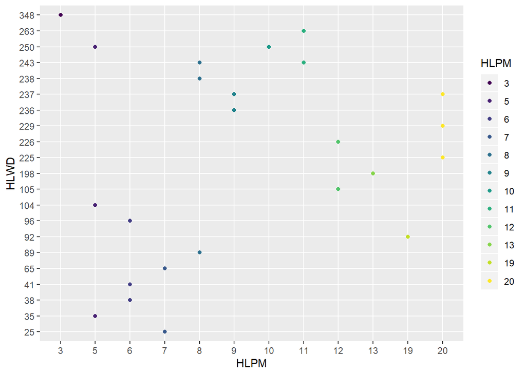

```r
ggplot(data = HLtotal)+
  geom_point(aes(x=HLPM,y=HLWD,color=HLPM))
```

# ——————————————————————————-花蓮ggplot

#——————————————————————————————金門

```r
a <- read.csv("空氣品質監測小時值金門.csv")
```

#選出需要的測項

```r
TEMP = filter(a, 測項.單位. %in% "溫度 AMB_TEMP (℃)")
WD = filter(a, 測項.單位. %in% "風向 WIND_DIREC (degrees)")
PM = filter(a, 測項.單位. %in% "細懸浮微粒 PM 2.5  (μg/m 3 )")
RH = filter(a, 測項.單位. %in% "相對濕度 RH (percent)")
```

#刪除1~6不要的數據

```r
for (x in (1:6))
{
  TEMP <- TEMP[ ,-1]
  WD <- WD[ ,-1]
  PM <- PM[ ,-1]
  RH <- RH[ ,-1]
}
```

#取數值

```r
KMTEMP <- filter(TEMP[1, ])
KMWD <- filter(WD[1, ])
KMPM <- filter(PM[1, ])
KMRH <- filter(RH[1, ])


KMTEMP <- t(KMTEMP)
KMTEMP <- data.frame(KMTEMP)
KMWD <- t(KMWD)
KMWD <- data.frame(KMWD)
KMPM <- t(KMPM)
KMPM <- data.frame(KMPM)
KMRH <- t(KMRH)
KMRH <- data.frame(KMRH)
```

#合併total

```r
KMtotal <- bind_cols(KMTEMP,KMWD,KMPM,KMRH)
```

#照數字大小排列!!沒做的話,排序會怪怪的

```r
KMtotal$KMPM <- factor(KMtotal$KMPM, levels = c(1:50 ), ordered = TRUE )
KMtotal$KMWD <- factor(KMtotal$KMWD, levels = c(1:360 ), ordered = TRUE )
```

#散佈圖

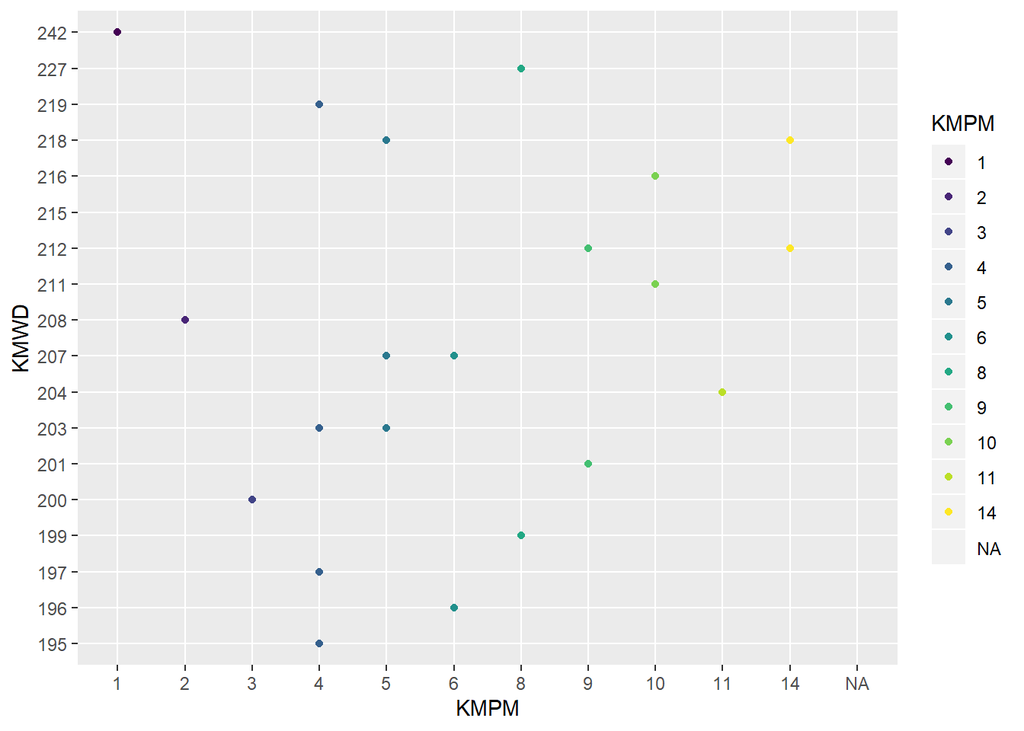

```r
ggplot(data = KMtotal)+
  geom_point(aes(x=KMPM,y=KMWD,color=KMPM))
```

# ——————————————————————————-金門ggplot

#——————————————————————————————南投

```r
a <- read.csv("空氣品質監測小時值南投.csv")
```

#選出需要的測項

```r
TEMP = filter(a, 測項.單位. %in% "溫度 AMB_TEMP (℃)")
WD = filter(a, 測項.單位. %in% "風向 WIND_DIREC (degrees)")
PM = filter(a, 測項.單位. %in% "細懸浮微粒 PM 2.5  (μg/m 3 )")
RH = filter(a, 測項.單位. %in% "相對濕度 RH (percent)")
```

#刪除1~6不要的數據

```r
for (x in (1:6))
{
  TEMP <- TEMP[ ,-1]
  WD <- WD[ ,-1]
  PM <- PM[ ,-1]
  RH <- RH[ ,-1]
}
```

#取數值

```r
NTTEMP <- filter(TEMP[1, ])
NTWD <- filter(WD[1, ])
NTPM <- filter(PM[1, ])
NTRH <- filter(RH[1, ])
```

#再和其他的合成一行

```r
for (i in 2)
{
  NTTEMP <- cbind(NTTEMP,filter(TEMP[i, ]))
  NTWD <- cbind(NTWD,filter(WD[i, ]))
  NTPM <- cbind(NTPM,filter(PM[i, ]))
  NTRH <- cbind(NTRH,filter(RH[i, ]))
}

NTTEMP <- t(NTTEMP)
NTTEMP <- data.frame(NTTEMP)
NTWD <- t(NTWD)
NTWD <- data.frame(NTWD)
NTPM <- t(NTPM)
NTPM <- data.frame(NTPM)
NTRH <- t(NTRH)
NTRH <- data.frame(NTRH)
```

#合併total

```r
NTtotal <- bind_cols(NTTEMP,NTWD,NTPM,NTRH)
```

#照數字大小排列!!沒做的話,排序會怪怪的

```r
NTtotal$NTPM <- factor(NTtotal$NTPM, levels = c(1:50 ), ordered = TRUE )
NTtotal$NTWD <- factor(NTtotal$NTWD, levels = c(1:360 ), ordered = TRUE )
```

#散佈圖

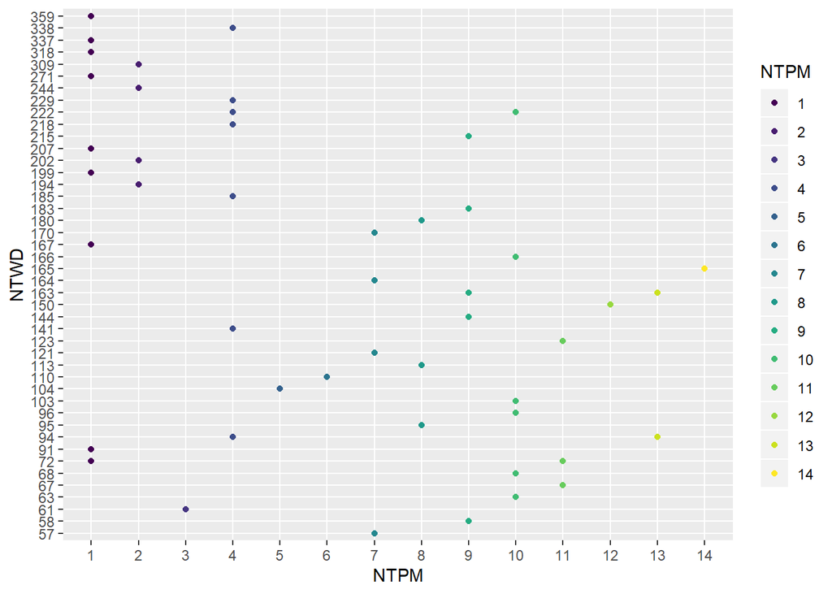

```r
ggplot(data = NTtotal)+
  geom_point(aes(x=NTPM,y=NTWD,color=NTPM))
```

# ——————————————————————————-南投ggplot

#——————————————————————————————屏東

```r
a <- read.csv("空氣品質監測小時值屏東.csv")
```

#選出需要的測項

```r
TEMP = filter(a, 測項.單位. %in% "溫度 AMB_TEMP (℃)")
WD = filter(a, 測項.單位. %in% "風向 WIND_DIREC (degrees)")
PM = filter(a, 測項.單位. %in% "細懸浮微粒 PM 2.5  (μg/m 3 )")
RH = filter(a, 測項.單位. %in% "相對濕度 RH (percent)")
```

#刪除1~6不要的數據

```r
for (x in (1:6))
{
  TEMP <- TEMP[ ,-1]
  WD <- WD[ ,-1]
  PM <- PM[ ,-1]
  RH <- RH[ ,-1]
}
```

#取數值

```r
PTTEMP <- filter(TEMP[1, ])
PTWD <- filter(WD[1, ])
PTPM <- filter(PM[1, ])
PTRH <- filter(RH[1, ])
```

#再和其他的合成一行

```r
for (i in 2:3)
{
  PTTEMP <- cbind(PTTEMP,filter(TEMP[i, ]))
  PTWD <- cbind(PTWD,filter(WD[i, ]))
  PTPM <- cbind(PTPM,filter(PM[i, ]))
  PTRH <- cbind(PTRH,filter(RH[i, ]))
}

PTTEMP <- t(PTTEMP)
PTTEMP <- data.frame(PTTEMP)
PTWD <- t(PTWD)
PTWD <- data.frame(PTWD)
PTPM <- t(PTPM)
PTPM <- data.frame(PTPM)
PTRH <- t(PTRH)
PTRH <- data.frame(PTRH)
```

#合併total

```r
PTtotal <- bind_cols(PTTEMP,PTWD,PTPM,PTRH)
```

#照數字大小排列!!沒做的話,排序會怪怪的

```r
PTtotal$PTPM <- factor(PTtotal$PTPM, levels = c(1:50 ), ordered = TRUE )
PTtotal$PTWD <- factor(PTtotal$PTWD, levels = c(1:360 ), ordered = TRUE )
```

#散佈圖

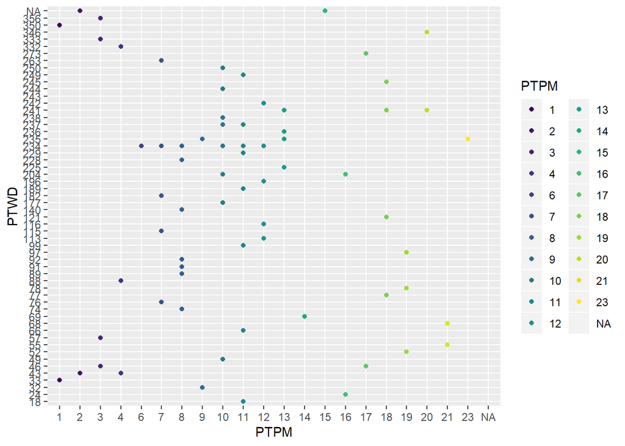

```r
ggplot(data = PTtotal)+
  geom_point(aes(x=PTPM,y=PTWD,color=PTPM))
```

# ——————————————————————————-屏東ggplot

#——————————————————————————————苗栗

```r
a <- read.csv("空氣品質監測小時值苗栗.csv")
```

#選出需要的測項

```r
TEMP = filter(a, 測項.單位. %in% "溫度 AMB_TEMP (℃)")
WD = filter(a, 測項.單位. %in% "風向 WIND_DIREC (degrees)")
PM = filter(a, 測項.單位. %in% "細懸浮微粒 PM 2.5  (μg/m 3 )")
RH = filter(a, 測項.單位. %in% "相對濕度 RH (percent)")
```

#刪除1~6不要的數據

```r
for (x in (1:6))
{
  TEMP <- TEMP[ ,-1]
  WD <- WD[ ,-1]
  PM <- PM[ ,-1]
  RH <- RH[ ,-1]
}
```

#取數值

```r
MLTEMP <- filter(TEMP[1, ])
MLWD <- filter(WD[1, ])
MLPM <- filter(PM[1, ])
MLRH <- filter(RH[1, ])
```

#再和其他的合成一行

```r
for (i in 2:3)
{
  MLTEMP <- cbind(MLTEMP,filter(TEMP[i, ]))
  MLWD <- cbind(MLWD,filter(WD[i, ]))
  MLPM <- cbind(MLPM,filter(PM[i, ]))
  MLRH <- cbind(MLRH,filter(RH[i, ]))
}

MLTEMP <- t(MLTEMP)
MLTEMP <- data.frame(MLTEMP)
MLWD <- t(MLWD)
MLWD <- data.frame(MLWD)
MLPM <- t(MLPM)
MLPM <- data.frame(MLPM)
MLRH <- t(MLRH)
MLRH <- data.frame(MLRH)
```

#合併total

```r
MLtotal <- bind_cols(MLTEMP,MLWD,MLPM,MLRH)
```

#照數字大小排列!!沒做的話,排序會怪怪的

```r
MLtotal$MLPM <- factor(MLtotal$MLPM, levels = c(1:50 ), ordered = TRUE )
MLtotal$MLWD <- factor(MLtotal$MLWD, levels = c(1:360 ), ordered = TRUE )
```

#散佈圖

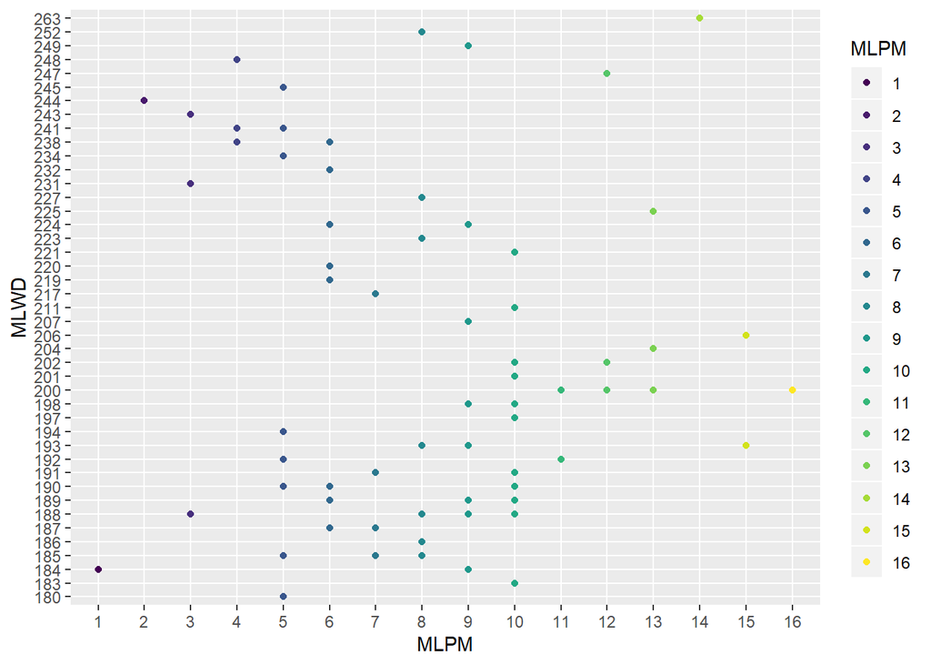

```r
ggplot(data = MLtotal)+
  geom_point(aes(x=MLPM,y=MLWD,color=MLPM))
```

# ——————————————————————————-苗栗ggplot

#——————————————————————————————桃園

```r
a <- read.csv("空氣品質監測小時值桃園.csv")
```

#選出需要的測項

```r
TEMP = filter(a, 測項.單位. %in% "溫度 AMB_TEMP (℃)")
WD = filter(a, 測項.單位. %in% "風向 WIND_DIREC (degrees)")
PM = filter(a, 測項.單位. %in% "細懸浮微粒 PM 2.5  (μg/m 3 )")
RH = filter(a, 測項.單位. %in% "相對濕度 RH (percent)")
```

#刪除1~6不要的數據

```r
for (x in (1:6))
{
  TEMP <- TEMP[ ,-1]
  WD <- WD[ ,-1]
  PM <- PM[ ,-1]
  RH <- RH[ ,-1]
}
```

#取數值

```r
TYTEMP <- filter(TEMP[1, ])
TYWD <- filter(WD[1, ])
TYPM <- filter(PM[1, ])
TYRH <- filter(RH[1, ])
```

#再和其他的合成一行

```r
for (i in 2:6)
{
  TYTEMP <- cbind(TYTEMP,filter(TEMP[i, ]))
  TYWD <- cbind(TYWD,filter(WD[i, ]))
  TYPM <- cbind(TYPM,filter(PM[i, ]))
  TYRH <- cbind(TYRH,filter(RH[i, ]))
}

TYTEMP <- t(TYTEMP)
TYTEMP <- data.frame(TYTEMP)
TYWD <- t(TYWD)
TYWD <- data.frame(TYWD)
TYPM <- t(TYPM)
TYPM <- data.frame(TYPM)
TYRH <- t(TYRH)
TYRH <- data.frame(TYRH)
```

#合併total

```r
TYtotal <- bind_cols(TYTEMP,TYWD,TYPM,TYRH)
```

#照數字大小排列!!沒做的話,排序會怪怪的

```r
TYtotal$TYPM <- factor(TYtotal$TYPM, levels = c(1:50 ), ordered = TRUE )
TYtotal$TYWD <- factor(TYtotal$TYWD, levels = c(1:360 ), ordered = TRUE )
```

#散佈圖

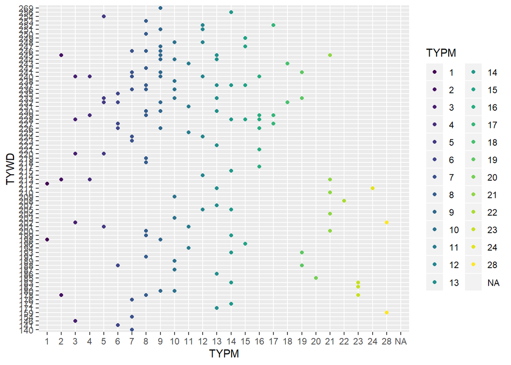

```r
ggplot(data = TYtotal)+
  geom_point(aes(x=TYPM,y=TYWD,color=TYPM))
```

# ——————————————————————————-桃園ggplot

#——————————————————————————————連江

```r
a <- read.csv("空氣品質監測小時值連江.csv")
```

#選出需要的測項

```r
TEMP = filter(a, 測項.單位. %in% "溫度 AMB_TEMP (℃)")
WD = filter(a, 測項.單位. %in% "風向 WIND_DIREC (degrees)")
PM = filter(a, 測項.單位. %in% "細懸浮微粒 PM 2.5  (μg/m 3 )")
RH = filter(a, 測項.單位. %in% "相對濕度 RH (percent)")
```

#刪除1~6不要的數據

```r
for (x in (1:6))
{
  TEMP <- TEMP[ ,-1]
  WD <- WD[ ,-1]
  PM <- PM[ ,-1]
  RH <- RH[ ,-1]
}
```

#取數值

```r
LCTEMP <- filter(TEMP[1, ])
LCWD <- filter(WD[1, ])
LCPM <- filter(PM[1, ])
LCRH <- filter(RH[1, ])


LCTEMP <- t(LCTEMP)
LCTEMP <- data.frame(LCTEMP)
LCWD <- t(LCWD)
LCWD <- data.frame(LCWD)
LCPM <- t(LCPM)
LCPM <- data.frame(LCPM)
LCRH <- t(LCRH)
LCRH <- data.frame(LCRH)
```

#合併total

```r
LCtotal <- bind_cols(LCTEMP,LCWD,LCPM,LCRH)
```

#照數字大小排列!!沒做的話,排序會怪怪的

```r
LCtotal$LCPM <- factor(LCtotal$LCPM, levels = c(1:50 ), ordered = TRUE )
LCtotal$LCWD <- factor(LCtotal$LCWD, levels = c(1:360 ), ordered = TRUE )
```

#散佈圖

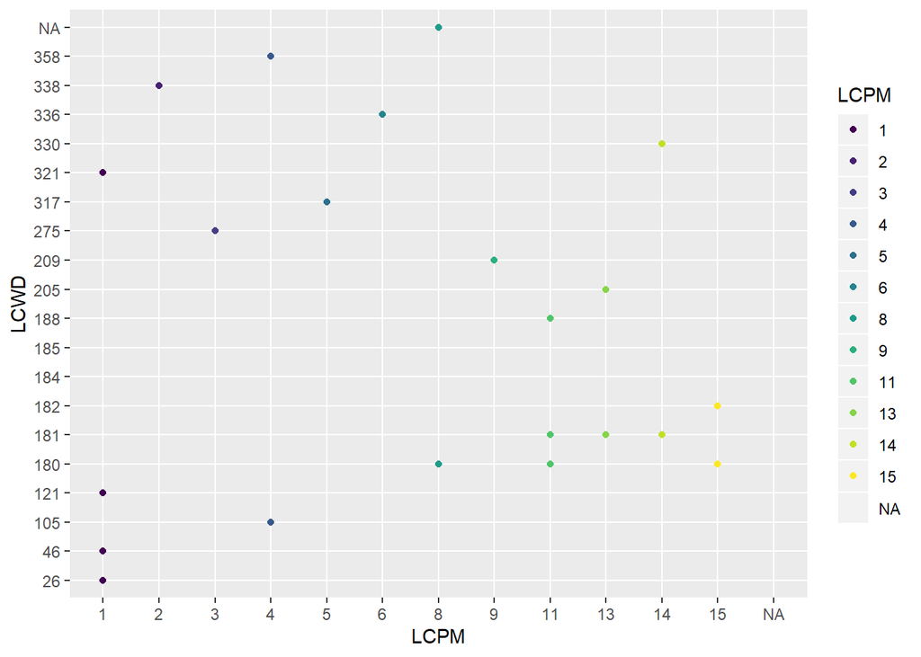

```r
ggplot(data = LCtotal)+
  geom_point(aes(x=LCPM,y=LCWD,color=LCPM))
```

# ——————————————————————————-連江ggplot

#——————————————————————————————高雄

```r
a <- read.csv("空氣品質監測小時值高雄.csv")
```

#選出需要的測項

```r
TEMP = filter(a, 測項.單位. %in% "溫度 AMB_TEMP (℃)")
WD = filter(a, 測項.單位. %in% "風向 WIND_DIREC (degrees)")
PM = filter(a, 測項.單位. %in% "細懸浮微粒 PM 2.5  (μg/m 3 )")
RH = filter(a, 測項.單位. %in% "相對濕度 RH (percent)")
```

#刪除多的一行(高雄的數據)

```r
WD = WD[-8, ]
RH = RH[-8, ]
TEMP = TEMP[-8, ]
```

#刪除1~6不要的數據

```r
for (x in (1:6))
{
  TEMP <- TEMP[ ,-1]
  WD <- WD[ ,-1]
  PM <- PM[ ,-1]
  RH <- RH[ ,-1]
}
```

#取數值

```r
KHTEMP <- filter(TEMP[1, ])
KHWD <- filter(WD[1, ])
KHPM <- filter(PM[1, ])
KHRH <- filter(RH[1, ])
```

#再和其他的合成一行

```r
for (i in 2:11)
{
  KHTEMP <- cbind(KHTEMP,filter(TEMP[i, ]))
  KHWD <- cbind(KHWD,filter(WD[i, ]))
  KHPM <- cbind(KHPM,filter(PM[i, ]))
  KHRH <- cbind(KHRH,filter(RH[i, ]))
}

KHTEMP <- t(KHTEMP)
KHTEMP <- data.frame(KHTEMP)
KHWD <- t(KHWD)
KHWD <- data.frame(KHWD)
KHPM <- t(KHPM)
KHPM <- data.frame(KHPM)
KHRH <- t(KHRH)
KHRH <- data.frame(KHRH)
```

#合併total

```r
KHtotal <- bind_cols(KHTEMP,KHWD,KHPM,KHRH)
```

#照數字大小排列!!沒做的話,排序會怪怪的

```r
KHtotal$KHPM <- factor(KHtotal$KHPM, levels = c(1:50 ), ordered = TRUE )
KHtotal$KHWD <- factor(KHtotal$KHWD, levels = c(1:360 ), ordered = TRUE )
```

#散佈圖

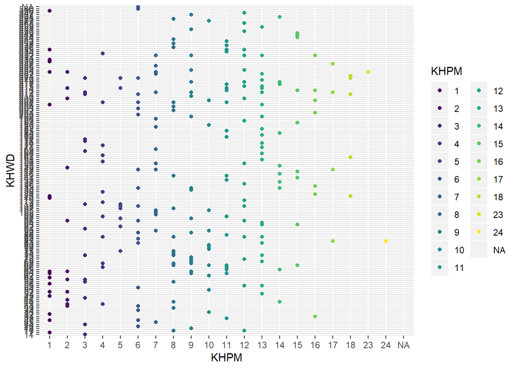

```r
ggplot(data = KHtotal)+
  geom_point(aes(x=KHPM,y=KHWD,color=KHPM))
```

# ——————————————————————————-高雄ggplot

#——————————————————————————————基隆

```r
a <- read.csv("空氣品質監測小時值基隆.csv")
```

#選出需要的測項

```r
TEMP = filter(a, 測項.單位. %in% "溫度 AMB_TEMP (℃)")
WD = filter(a, 測項.單位. %in% "風向 WIND_DIREC (degrees)")
PM = filter(a, 測項.單位. %in% "細懸浮微粒 PM 2.5  (μg/m 3 )")
RH = filter(a, 測項.單位. %in% "相對濕度 RH (percent)")
```

#刪除1~6不要的數據

```r
for (x in (1:6))
{
  TEMP <- TEMP[ ,-1]
  WD <- WD[ ,-1]
  PM <- PM[ ,-1]
  RH <- RH[ ,-1]
}
```

#取數值

```r
KLTEMP <- filter(TEMP[1, ])
KLWD <- filter(WD[1, ])
KLPM <- filter(PM[1, ])
KLRH <- filter(RH[1, ])


KLTEMP <- t(KLTEMP)
KLTEMP <- data.frame(KLTEMP)
KLWD <- t(KLWD)
KLWD <- data.frame(KLWD)
KLPM <- t(KLPM)
KLPM <- data.frame(KLPM)
KLRH <- t(KLRH)
KLRH <- data.frame(KLRH)
```

#合併total

```r
KLtotal <- bind_cols(KLTEMP,KLWD,KLPM,KLRH)
```

#照數字大小排列!!沒做的話,排序會怪怪的

```r
KLtotal$KLPM <- factor(KLtotal$KLPM, levels = c(1:50 ), ordered = TRUE )
KLtotal$KLWD <- factor(KLtotal$KLWD, levels = c(1:360 ), ordered = TRUE )
```

#散佈圖

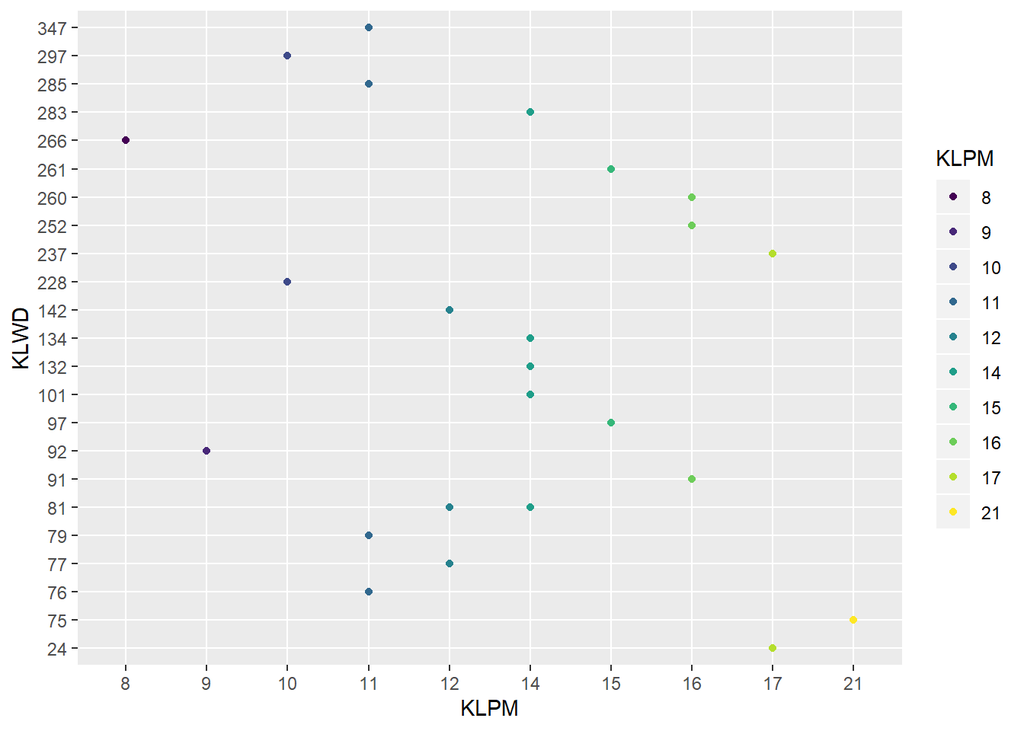

```r
ggplot(data = KLtotal)+
  geom_point(aes(x=KLPM,y=KLWD,color=KLPM))
```

# ——————————————————————————-基隆ggplot

#——————————————————————————————雲林

```r
a <- read.csv("空氣品質監測小時值雲林.csv")
```

#選出需要的測項

```r
TEMP = filter(a, 測項.單位. %in% "溫度 AMB_TEMP (℃)")
WD = filter(a, 測項.單位. %in% "風向 WIND_DIREC (degrees)")
PM = filter(a, 測項.單位. %in% "細懸浮微粒 PM 2.5  (μg/m 3 )")
RH = filter(a, 測項.單位. %in% "相對濕度 RH (percent)")
```

#刪除1~6不要的數據

```r
for (x in (1:6))
{
  TEMP <- TEMP[ ,-1]
  WD <- WD[ ,-1]
  PM <- PM[ ,-1]
  RH <- RH[ ,-1]
}
```

#取數值

```r
YLTEMP <- filter(TEMP[1, ])
YLWD <- filter(WD[1, ])
YLPM <- filter(PM[1, ])
YLRH <- filter(RH[1, ])
```

#再和其他的合成一行

```r
for (i in 2:4)
{
  YLTEMP <- cbind(YLTEMP,filter(TEMP[i, ]))
  YLWD <- cbind(YLWD,filter(WD[i, ]))
  YLPM <- cbind(YLPM,filter(PM[i, ]))
  YLRH <- cbind(YLRH,filter(RH[i, ]))
}

YLTEMP <- t(YLTEMP)
YLTEMP <- data.frame(YLTEMP)
YLWD <- t(YLWD)
YLWD <- data.frame(YLWD)
YLPM <- t(YLPM)
YLPM <- data.frame(YLPM)
YLRH <- t(YLRH)
YLRH <- data.frame(YLRH)
```

#合併total

```r
YLtotal <- bind_cols(YLTEMP,YLWD,YLPM,YLRH)
```

#照數字大小排列!!沒做的話,排序會怪怪的

```r
YLtotal$YLPM <- factor(YLtotal$YLPM, levels = c(1:50 ), ordered = TRUE )
YLtotal$YLWD <- factor(YLtotal$YLWD, levels = c(1:360 ), ordered = TRUE )
```

#散佈圖

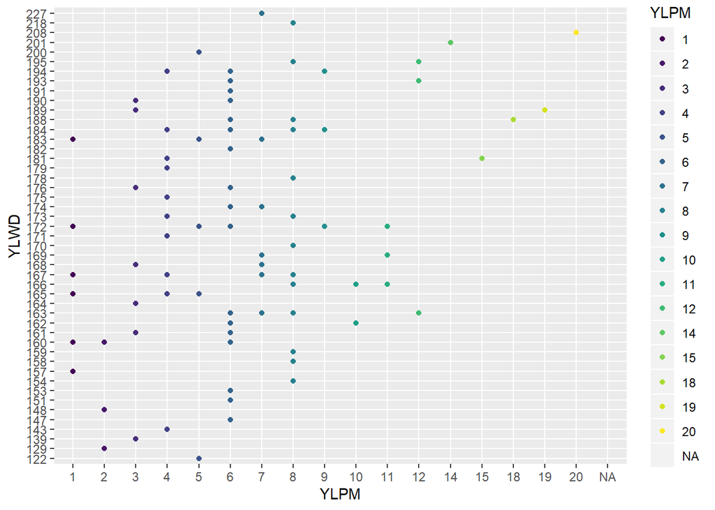

```r
ggplot(data = YLtotal)+
  geom_point(aes(x=YLPM,y=YLWD,color=YLPM))
```

# ——————————————————————————-雲林ggplot

#——————————————————————————————新竹市

```r
a <- read.csv("空氣品質監測小時值新竹市.csv")
```

#選出需要的測項

```r
TEMP = filter(a, 測項.單位. %in% "溫度 AMB_TEMP (℃)")
WD = filter(a, 測項.單位. %in% "風向 WIND_DIREC (degrees)")
PM = filter(a, 測項.單位. %in% "細懸浮微粒 PM 2.5  (μg/m 3 )")
RH = filter(a, 測項.單位. %in% "相對濕度 RH (percent)")
```

#刪除1~6不要的數據

```r
for (x in (1:6))
{
  TEMP <- TEMP[ ,-1]
  WD <- WD[ ,-1]
  PM <- PM[ ,-1]
  RH <- RH[ ,-1]
}
```

#取數值

```r
HCTTEMP <- filter(TEMP[1, ])
HCTWD <- filter(WD[1, ])
HCTPM <- filter(PM[1, ])
HCTRH <- filter(RH[1, ])


HCTTEMP <- t(HCTTEMP)
HCTTEMP <- data.frame(HCTTEMP)
HCTWD <- t(HCTWD)
HCTWD <- data.frame(HCTWD)
HCTPM <- t(HCTPM)
HCTPM <- data.frame(HCTPM)
HCTRH <- t(HCTRH)
HCTRH <- data.frame(HCTRH)
```

#合併total

```r
HCTtotal <- bind_cols(HCTTEMP,HCTWD,HCTPM,HCTRH)
```

#照數字大小排列!!沒做的話,排序會怪怪的

```r
HCTtotal$HCTPM <- factor(HCTtotal$HCTPM, levels = c(1:50 ), ordered = TRUE )
HCTtotal$HCTWD <- factor(HCTtotal$HCTWD, levels = c(1:360 ), ordered = TRUE )
```

#散佈圖

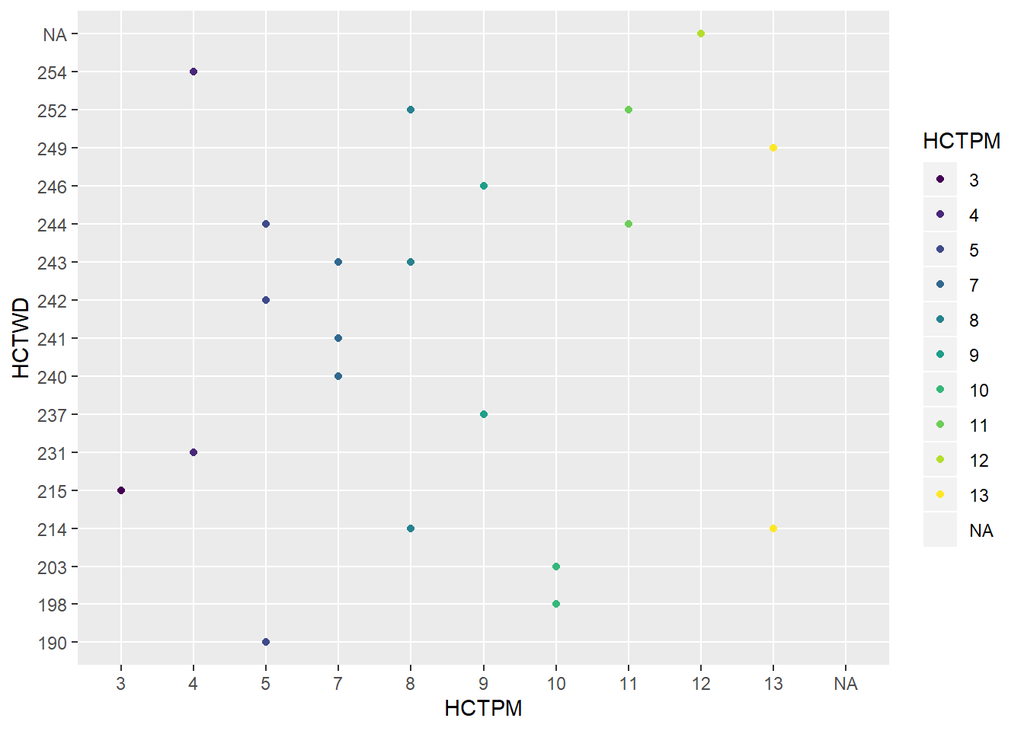

```r
ggplot(data = HCTtotal)+
  geom_point(aes(x=HCTPM,y=HCTWD,color=HCTPM))
```

# ——————————————————————————-新竹市ggplot

# 從散佈圖看出，空氣差似乎和風向沒有直接關係

# 於是把各縣市PM.25平均值做個比較

#————————————————————————–取各縣市PM2.5平均值

#需先把數值轉成CHAR再轉NUM,才不會出現不是數字的錯誤

```r
HCTPM2.5avg <- as.numeric(as.character(HCTPM$HCTPM, na.rm = TRUE))
HCTPM2.5avg <- data.frame(HCTPM2.5avg)
HCTPM2.5avg <- (colMeans(HCTPM2.5avg, na.rm = TRUE))


HLPM2.5avg <- as.numeric(as.character(HLPM$HLPM, na.rm = TRUE))
HLPM2.5avg <- data.frame(HLPM2.5avg)
HLPM2.5avg <- (colMeans(HLPM2.5avg, na.rm = TRUE))

ILPM2.5avg <- as.numeric(as.character(ILPM$ILPM, na.rm = TRUE))
ILPM2.5avg <- data.frame(ILPM2.5avg)
ILPM2.5avg <- (colMeans(ILPM2.5avg, na.rm = TRUE))

KHPM2.5avg <- as.numeric(as.character(KHPM$KHPM, na.rm = TRUE))
KHPM2.5avg <- data.frame(KHPM2.5avg)
KHPM2.5avg <- (colMeans(KHPM2.5avg, na.rm = TRUE))

KLPM2.5avg <- as.numeric(as.character(KLPM$KLPM, na.rm = TRUE))
KLPM2.5avg <- data.frame(KLPM2.5avg)
KLPM2.5avg <- (colMeans(KLPM2.5avg, na.rm = TRUE))

KMPM2.5avg <- as.numeric(as.character(KMPM$KMPM, na.rm = TRUE))
KMPM2.5avg <- data.frame(KMPM2.5avg)
KMPM2.5avg <- (colMeans(KMPM2.5avg, na.rm = TRUE))

LCPM2.5avg <- as.numeric(as.character(LCPM$LCPM, na.rm = TRUE))
LCPM2.5avg <- data.frame(LCPM2.5avg)
LCPM2.5avg <- (colMeans(LCPM2.5avg, na.rm = TRUE))

MLPM2.5avg <- as.numeric(as.character(MLPM$MLPM, na.rm = TRUE))
MLPM2.5avg <- data.frame(MLPM2.5avg)
MLPM2.5avg <- (colMeans(MLPM2.5avg, na.rm = TRUE))

NTPM2.5avg <- as.numeric(as.character(NTPM$NTPM, na.rm = TRUE))
NTPM2.5avg <- data.frame(NTPM2.5avg)
NTPM2.5avg <- (colMeans(NTPM2.5avg, na.rm = TRUE))

PTPM2.5avg <- as.numeric(as.character(PTPM$PTPM, na.rm = TRUE))
PTPM2.5avg <- data.frame(PTPM2.5avg)
PTPM2.5avg <- (colMeans(PTPM2.5avg, na.rm = TRUE))

TCPM2.5avg <- as.numeric(as.character(TCPM$TCPM, na.rm = TRUE))
TCPM2.5avg <- data.frame(TCPM2.5avg)
TCPM2.5avg <- (colMeans(TCPM2.5avg, na.rm = TRUE))

TNPM2.5avg <- as.numeric(as.character(TNPM$TNPM, na.rm = TRUE))
TNPM2.5avg <- data.frame(TNPM2.5avg)
TNPM2.5avg <- (colMeans(TNPM2.5avg, na.rm = TRUE))

TPPM2.5avg <- as.numeric(as.character(TPPM$TPPM, na.rm = TRUE))
TPPM2.5avg <- data.frame(TPPM2.5avg)
TPPM2.5avg <- (colMeans(TPPM2.5avg, na.rm = TRUE))

TTPM2.5avg <- as.numeric(as.character(TTPM$TTPM, na.rm = TRUE))
TTPM2.5avg <- data.frame(TTPM2.5avg)
TTPM2.5avg <- (colMeans(TTPM2.5avg, na.rm = TRUE))

TYPM2.5avg <- as.numeric(as.character(TYPM$TYPM, na.rm = TRUE))
TYPM2.5avg <- data.frame(TYPM2.5avg)
TYPM2.5avg <- (colMeans(TYPM2.5avg, na.rm = TRUE))

YLPM2.5avg <- as.numeric(as.character(YLPM$YLPM, na.rm = TRUE))
YLPM2.5avg <- data.frame(YLPM2.5avg)
YLPM2.5avg <- (colMeans(YLPM2.5avg, na.rm = TRUE))

#total
PM2.5avgtotal <- data.frame(cbind(HCTPM2.5avg,HLPM2.5avg,ILPM2.5avg,KHPM2.5avg,KLPM2.5avg,KMPM2.5avg,LCPM2.5avg,MLPM2.5avg,NTPM2.5avg,PTPM2.5avg,TCPM2.5avg,TNPM2.5avg,TPPM2.5avg,TTPM2.5avg,TYPM2.5avg,YLPM2.5avg))

ALLavg <- t(PM2.5avgtotal)
ALLavg <- data.frame(ALLavg)

#加一欄縣市名稱
ALLavg$地區 <- c("新竹市","花蓮","宜蘭","高雄","基隆","金門","連江","苗栗","南投","屏東","台中","台南","台北","台東","桃園","雲林")
#看一下數據大小
ALLavg <- ALLavg[order(ALLavg$HCTPM2.5avg, decreasing = FALSE), ]
ALLavg <- data.frame(ALLavg)
```

#——————————————————————————-各縣市PM2.5平均值ggplot

# 各縣市PM2.5直條圖

#先排列[地區]順序

```r
ALLavg$地區 <- factor(ALLavg$地區, levels = c("南投","雲林","金門","連江","新竹市","苗栗","高雄","台中","花蓮","台南","台東","屏東","桃園","台北","基隆","宜蘭"), ordered = TRUE )
```

#長條圖

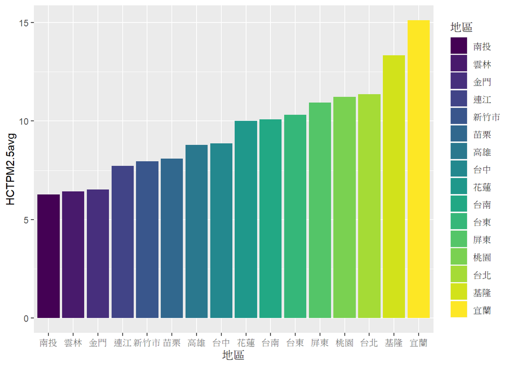

```r
ggplot(ALLavg,aes(x=地區,y=HCTPM2.5avg, fill=地區))+geom_bar(stat="identity",position="dodge")
```

#### 結論:一開始用了散佈圖來觀察，發現[空氣差]和[風向]沒有直接關係，於是又畫了直條圖來觀察各縣市的空氣品質，發現其實東北部反而比西南部空氣差!?

###### 其實一開始有抓了每個縣市的DATA，但是再轉HTML時轉不出來，發生了(maximum recursion depth reached.),結果後來程式重灌就可以了…